# Sleep Health and Lifestyle

Author

Mert Baki Dogan

Published

January 22, 2026

# Aufgabenstellung und Daten verstehen

In dieser Arbeit soll untersucht werden, wie sich verschiedene Faktoren auf die Schlafqualität auswirken. Dabei geht es nicht nur darum, ob sich diese Faktoren auswirken, sondern auch, wie stark ihr Einfluss ist. Anschließend soll ein regressives Machine-Learning-Modell trainiert werden, das die Schlafqualität vorhersagt.

Dazu steht uns der Datensatz *Sleep Health and Lifestyle Dataset* zur Verfügung. Dieser Datensatz enthält Informationen über den Lebensstil und die Schlafqualität verschiedener Personen. Er ist unter folgendem Link zu finden: https://www.kaggle.com/datasets/uom190346a/sleep-health-and-lifestyle-dataset

Zu Beginn formulieren wir zwei Thesen, die wir mit Hilfe des Datensatzes überprüfen möchten.

**These 1: Wenig Stress und viel körperliche Aktivität haben einen großen Einfluss auf eine gute Schlafqualität**

**These 2: Mit dem Alter nimmt die Schlafqualität ab**

Diese Thesen sollen explorativ untersucht werden und kommen eventuell in der Modellfindung zum Einsatz. Weitere Thesen werden sich eventuell bei der Sichtung der Daten ergeben.

Im nächsten Schritt werden die Daten eingelesen.

**Code anzeigen**

```r
sleep_data <- read.csv("Sleep_health_and_lifestyle_dataset.csv")
```

Schauen wir uns die Daten zunächst einmal an.

**Code anzeigen**

```r
knitr::kable(head(sleep_data), caption = "Das Spaltenformat des eingelesenen Datensatzes")
```

Das Spaltenformat des eingelesenen Datensatzes

| Person.ID | Gender | Age | Occupation | Sleep.Duration | Quality.of.Sleep | Physical.Activity.Level | Stress.Level | BMI.Category | Blood.Pressure | Heart.Rate | Daily.Steps | Sleep.Disorder |
| --- | --- | --- | --- | --- | --- | --- | --- | --- | --- | --- | --- | --- |
| 1 | Male | 27 | Software Engineer | 6.1 | 6 | 42 | 6 | Overweight | 126/83 | 77 | 4200 | None |
| 2 | Male | 28 | Doctor | 6.2 | 6 | 60 | 8 | Normal | 125/80 | 75 | 10000 | None |
| 3 | Male | 28 | Doctor | 6.2 | 6 | 60 | 8 | Normal | 125/80 | 75 | 10000 | None |
| 4 | Male | 28 | Sales Representative | 5.9 | 4 | 30 | 8 | Obese | 140/90 | 85 | 3000 | Sleep Apnea |
| 5 | Male | 28 | Sales Representative | 5.9 | 4 | 30 | 8 | Obese | 140/90 | 85 | 3000 | Sleep Apnea |
| 6 | Male | 28 | Software Engineer | 5.9 | 4 | 30 | 8 | Obese | 140/90 | 85 | 3000 | Insomnia |

Der Datensatz hat **374** Zeilen und **13** Spalten.

Die Variablen haben folgende Bedeutung:

| Variable | Type | Bedeutung |
| --- | --- | --- |
| Person.ID | int | Kennung für jede Person |
| Gender | chr | Geschlecht (“Male”/“Female”) |
| Age | int | Alter |
| Occupation | chr | Beruf |
| Sleep.Duration | dbl | Anzahl der Stunden, die die Person am Tag schläft |
| Quality.of.Sleep | int | Subjektive Bewertung der Schlafqualität (1-10) |
| Physical.Activity.Level | int | Tägliche Aktivität in Minuten |
| Stress.Level | int | Subjektive Bewertung des Stresslevels (1-10) |
| BMI.Category | chr | BMI Kategorie |
| Blood.Pressure | char | Blutdruck (systolisch/diastolisch) |
| Heart.Rate | int | Ruheherzfrequenz |
| Daily.Steps | int | Tägliche Schritte |
| Sleep.Disorder | chr | Schlafstörung (Keine, Insomnie, Schlafapnoe) |

Zunächst verschaffen wir uns einen Überblick über die Daten.

**Code anzeigen**

```r
glimpse(sleep_data)
```

```
Rows: 374
Columns: 13
$ Person.ID               <int> 1, 2, 3, 4, 5, 6, 7, 8, 9, 10, 11, 12, 13, 14,…
$ Gender                  <chr> "Male", "Male", "Male", "Male", "Male", "Male"…
$ Age                     <int> 27, 28, 28, 28, 28, 28, 29, 29, 29, 29, 29, 29…
$ Occupation              <chr> "Software Engineer", "Doctor", "Doctor", "Sale…
$ Sleep.Duration          <dbl> 6.1, 6.2, 6.2, 5.9, 5.9, 5.9, 6.3, 7.8, 7.8, 7…
$ Quality.of.Sleep        <int> 6, 6, 6, 4, 4, 4, 6, 7, 7, 7, 6, 7, 6, 6, 6, 6…
$ Physical.Activity.Level <int> 42, 60, 60, 30, 30, 30, 40, 75, 75, 75, 30, 75…
$ Stress.Level            <int> 6, 8, 8, 8, 8, 8, 7, 6, 6, 6, 8, 6, 8, 8, 8, 8…
$ BMI.Category            <chr> "Overweight", "Normal", "Normal", "Obese", "Ob…
$ Blood.Pressure          <chr> "126/83", "125/80", "125/80", "140/90", "140/9…
$ Heart.Rate              <int> 77, 75, 75, 85, 85, 85, 82, 70, 70, 70, 70, 70…
$ Daily.Steps             <int> 4200, 10000, 10000, 3000, 3000, 3000, 3500, 80…
$ Sleep.Disorder          <chr> "None", "None", "None", "Sleep Apnea", "Sleep …
```

**Code anzeigen**

```r
sleep_data %>% describe()
```

```
# A tibble: 13 × 8
   variable                type     na na_pct unique    min    mean     max
   <chr>                   <chr> <int>  <dbl>  <int>  <dbl>   <dbl>   <dbl>
 1 Person.ID               int       0      0    374    1    188.     374
 2 Gender                  chr       0      0      2   NA     NA       NA
 3 Age                     int       0      0     31   27     42.2     59
 4 Occupation              chr       0      0     11   NA     NA       NA
 5 Sleep.Duration          dbl       0      0     27    5.8    7.13     8.5
 6 Quality.of.Sleep        int       0      0      6    4      7.31     9
 7 Physical.Activity.Level int       0      0     16   30     59.2     90
 8 Stress.Level            int       0      0      6    3      5.39     8
 9 BMI.Category            chr       0      0      4   NA     NA       NA
10 Blood.Pressure          chr       0      0     25   NA     NA       NA
11 Heart.Rate              int       0      0     19   65     70.2     86
12 Daily.Steps             int       0      0     20 3000   6817.   10000
13 Sleep.Disorder          chr       0      0      3   NA     NA       NA
```

**Code anzeigen**

```r
sleep_data %>% describe_tbl()
```

```
374 observations with 13 variables
0 observations containing missings (NA)
0 variables containing missings (NA)
0 variables with no variance
```

*Person.ID* nummeriert lediglich die verschiedenen Personen durch und ist deshalb für uns nicht relevant. Auch die Variable *Occupation* liefert uns keine relevanten Informationen. Aus diesem Grund werden wir *Person.ID* und *Occupation* später aus dem Datensatz entfernen.

Die restlichen Variablen könnten einen Einfluss auf die Schlafqualität haben. Auch wenn wir nicht alle in der explorativen Datenanalyse verwenden, könnten sie uns trotzdem später beim Trainieren des Modells helfen.

**Code anzeigen**

```r
summary(sleep_data)
```

```
   Person.ID         Gender               Age         Occupation
 Min.   :  1.00   Length:374         Min.   :27.00   Length:374
 1st Qu.: 94.25   Class :character   1st Qu.:35.25   Class :character
 Median :187.50   Mode  :character   Median :43.00   Mode  :character
 Mean   :187.50                      Mean   :42.18
 3rd Qu.:280.75                      3rd Qu.:50.00
 Max.   :374.00                      Max.   :59.00
 Sleep.Duration  Quality.of.Sleep Physical.Activity.Level  Stress.Level
 Min.   :5.800   Min.   :4.000    Min.   :30.00           Min.   :3.000
 1st Qu.:6.400   1st Qu.:6.000    1st Qu.:45.00           1st Qu.:4.000
 Median :7.200   Median :7.000    Median :60.00           Median :5.000
 Mean   :7.132   Mean   :7.313    Mean   :59.17           Mean   :5.385
 3rd Qu.:7.800   3rd Qu.:8.000    3rd Qu.:75.00           3rd Qu.:7.000
 Max.   :8.500   Max.   :9.000    Max.   :90.00           Max.   :8.000
 BMI.Category       Blood.Pressure       Heart.Rate     Daily.Steps
 Length:374         Length:374         Min.   :65.00   Min.   : 3000
 Class :character   Class :character   1st Qu.:68.00   1st Qu.: 5600
 Mode  :character   Mode  :character   Median :70.00   Median : 7000
                                       Mean   :70.17   Mean   : 6817
                                       3rd Qu.:72.00   3rd Qu.: 8000
                                       Max.   :86.00   Max.   :10000
 Sleep.Disorder
 Length:374
 Class :character
 Mode  :character
```

Wenn wir uns die Summary anschauen, können wir keine Auffälligkeiten feststellen. Alle Daten wirken realistisch.

# Daten aufbereiten

Erstellen wir unseren finalen Datensatz und entfernen die Variablen *Person.ID* und *Occupation*, da diese für unseren Kontext nicht relevant sind.

**Code anzeigen**

```r
final_sleep_data <-
  sleep_data %>%
  select(-Person.ID, -Occupation)
```

Das Geschlecht ist eine kategorische Variable. Wandeln wir sie für eine einfachere Weiterverarbeitung in einen Faktor um.

**Code anzeigen**

```r
final_sleep_data$Gender <-
  as.factor(final_sleep_data$Gender)
```

Da für uns es nicht relevant ist, um welche Schlafstörung es sich genau handelt, geben wir nur an, ob eine Schlafstörung vorhanden ist.

**Code anzeigen**

```r
final_sleep_data <-
  final_sleep_data %>%
  mutate(Sleep.Disorder = Sleep.Disorder != "None")
```

Um die Lesbarkeit zu verbessern, wandeln wir die *Sleep.Disorder* Variable, in zwei Kategorien um.

**Code anzeigen**

```r
final_sleep_data$Sleep.Disorder <-
  if_else(final_sleep_data$Sleep.Disorder, "Hat Schlafstörung", "Hat keine Schlafstörung") %>%
  as_factor()
```

Um die Weiterverarbeitung zu vereinfachen, wandeln wir die *BMI.Category* zu einem Faktor um. Dabei werden wir auch die Reihenfolge der Kategorien beachten.

Dazu schauen wir uns erst einmal an, welche Kategorien in *BMI.Category* enthalten sind.

**Code anzeigen**

```r
unique(final_sleep_data$BMI.Category)
```

```
[1] "Overweight"    "Normal"        "Obese"         "Normal Weight"
```

Die Kategorien *Normal* und *Normal Weight* scheinen dieselben zu sein. Also ersetzen wir *Normal* mit *Normal Weight*.

**Code anzeigen**

```r
final_sleep_data <- final_sleep_data %>%
  mutate(BMI.Category = replace(BMI.Category, BMI.Category == "Normal", "Normal Weight"))

unique(final_sleep_data$BMI.Category)
```

```
[1] "Overweight"    "Normal Weight" "Obese"
```

Das ergibt 3 Kategorien. Sortiert werden die Kategorien: *“Normal Weight” < “Overweight” < “Obese”*

**Code anzeigen**

```r
final_sleep_data$BMI.Category <-
  final_sleep_data$BMI.Category %>%
  factor(
    levels = c("Normal Weight","Overweight", "Obese"),
    ordered = TRUE
    )

unique(final_sleep_data$BMI.Category)
```

```
[1] Overweight    Normal Weight Obese
Levels: Normal Weight < Overweight < Obese
```

Die Variable *Blood.Pressure* ist als String im Datensatz. Wir teilen die Variable in den systolischen und diastolischen Wert auf und wandeln sie in einen Integer um.

**Code anzeigen**

```r
final_sleep_data <-
  final_sleep_data %>%
  separate_wider_delim(
    Blood.Pressure,
    delim = "/",
    names = c("BD.Systolisch", "BD.Diastolisch"),
  ) %>%
  mutate(
    BD.Systolisch = as.integer(BD.Systolisch),
    BD.Diastolisch = as.integer(BD.Diastolisch)
  )
```

Am Ende werfen wir noch einen kurzen Blick in den finalen Datensatz.

**Code anzeigen**

```r
knitr::kable(head(final_sleep_data), caption = "Der finale Datensatz")
```

Der finale Datensatz

| Gender | Age | Sleep.Duration | Quality.of.Sleep | Physical.Activity.Level | Stress.Level | BMI.Category | BD.Systolisch | BD.Diastolisch | Heart.Rate | Daily.Steps | Sleep.Disorder |
| --- | --- | --- | --- | --- | --- | --- | --- | --- | --- | --- | --- |
| Male | 27 | 6.1 | 6 | 42 | 6 | Overweight | 126 | 83 | 77 | 4200 | Hat keine Schlafstörung |
| Male | 28 | 6.2 | 6 | 60 | 8 | Normal Weight | 125 | 80 | 75 | 10000 | Hat keine Schlafstörung |
| Male | 28 | 6.2 | 6 | 60 | 8 | Normal Weight | 125 | 80 | 75 | 10000 | Hat keine Schlafstörung |
| Male | 28 | 5.9 | 4 | 30 | 8 | Obese | 140 | 90 | 85 | 3000 | Hat Schlafstörung |
| Male | 28 | 5.9 | 4 | 30 | 8 | Obese | 140 | 90 | 85 | 3000 | Hat Schlafstörung |
| Male | 28 | 5.9 | 4 | 30 | 8 | Obese | 140 | 90 | 85 | 3000 | Hat Schlafstörung |

Nachdem wir den Datensatz fertig aufbereitet haben, widmen wir uns unserer ersten These.

# Modell bilden

## Testdaten beiseitelegen

Damit sich keine Data-Snooping-Bias entwickelt, legen wir bereits am Anfang einen Teil der Daten beiseite. Diese werden wir dann am Ende dazu verwenden, um das Modell auf noch nicht gesehene Daten zu testen.

**Code anzeigen**

```r
set.seed(1337)
sleep_data_split <- initial_split(final_sleep_data, prop = 0.80, Quality.of.Sleep)
sleep_data_split
```

```
<Training/Testing/Total>
<297/77/374>
```

**Code anzeigen**

```r
final_sleep_data_train <- training(sleep_data_split)
final_sleep_data_test <- testing(sleep_data_split)
final_sleep_data <- final_sleep_data_train
```

## Explorative Datenanalyse

### Untersuchung der ersten These

Zunächst untersuchen wir, wie sich Stress auf die Schlafqualität auswirkt. Dabei vergleichen wir die Variable *Stress.Level* mit der Variable *Quality.of.Sleep*.

**Code anzeigen**

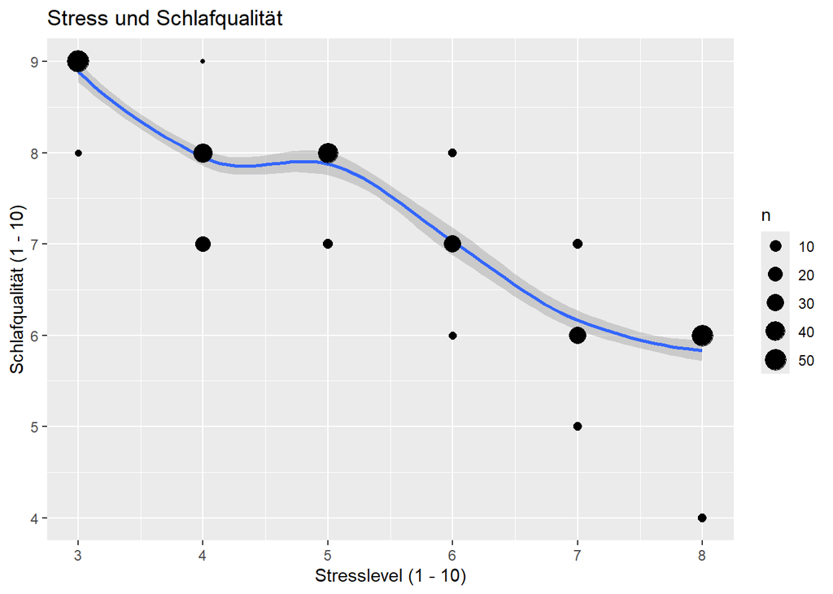

```r
ggplot(
  data = final_sleep_data,
  mapping = aes(x = Stress.Level, y = Quality.of.Sleep)
) +
  geom_smooth() +
  geom_count() +
  labs(
    title = "Stress und Schlafqualität",
    x = "Stresslevel (1 - 10)",
    y = "Schlafqualität (1 - 10)"
  )
```

Die Grafik zeigt, dass die Schlafqualität mit zunehmendem Stress abnimmt. Sie hat eine starke negative Korrelation von **-0.8982828**

Die Schlafqualität bleibt in einem Bereich von 4 bis 9. Wobei der Durchschnitt **7.3164983** beträgt.

Dabei ist zu beachten, dass es sich um subjektive Daten handelt. Um ein genaueres Bild zu erhalten, betrachten wir im Folgenden, wie sich Stress auf die Schlafstörungen auswirkt. Dazu betrachten wir, wie groß der Anteil der Personen ist, die an Schlafstörungen leiden.

**Code anzeigen**

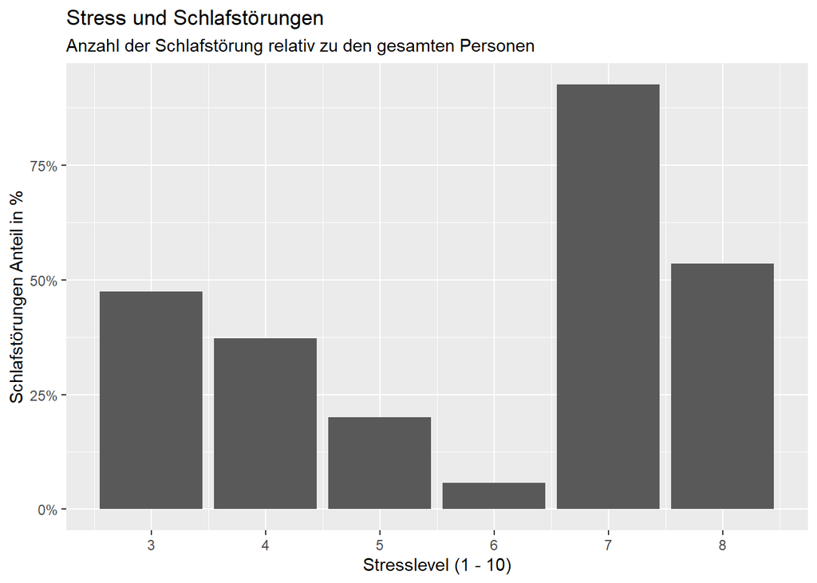

```r
stress_sleep_dis <- final_sleep_data %>%
  group_by(Stress.Level) %>%
  summarise(
    percent_sleep_disorder = sum(Sleep.Disorder == "Hat Schlafstörung") / (sum(Sleep.Disorder == "Hat keine Schlafstörung") + sum(Sleep.Disorder == "Hat Schlafstörung"))
  )

stress_sleep_dis %>%
  ggplot(mapping = aes(x = Stress.Level, y = percent_sleep_disorder)) +
  geom_col() +
  scale_x_continuous(breaks = 1:10) +
  scale_y_continuous(labels = scales::percent) +
  labs(
    title = "Stress und Schlafstörungen",
    subtitle = "Anzahl der Schlafstörung relativ zu den gesamten Personen",
    x = "Stresslevel (1 - 10)",
    y = "Schlafstörungen Anteil in %"
  )
```

Wie zu erkennen ist, liegt der Anteil der Schlafstörungen bei einem Stresslevel von 1 bis 6 unter 50 Prozent. Man kann sogar einen Abfall der Schlafstörungen bis zu einem Stresslevel von 6 erkennen. Ab dem Stresslevel von 6 steigt der Anteil der Schlafstörungen jedoch deutlich an.

Trotz des anfänglichen Rückgangs kann man sagen, dass ein höheres Stresslevel mit einem erhöhten Auftreten von Schlafstörungen einhergeht.

Damit bestätigen sich die vorherigen Ergebnisse und man kann sagen:

**Ein hohes Level an Stress wirkt sich negativ auf die Schlafqualität aus.**

Schauen wir uns als nächstes an, wie sich körperliche Aktivität auf die Schlafqualität auswirkt.

**Code anzeigen**

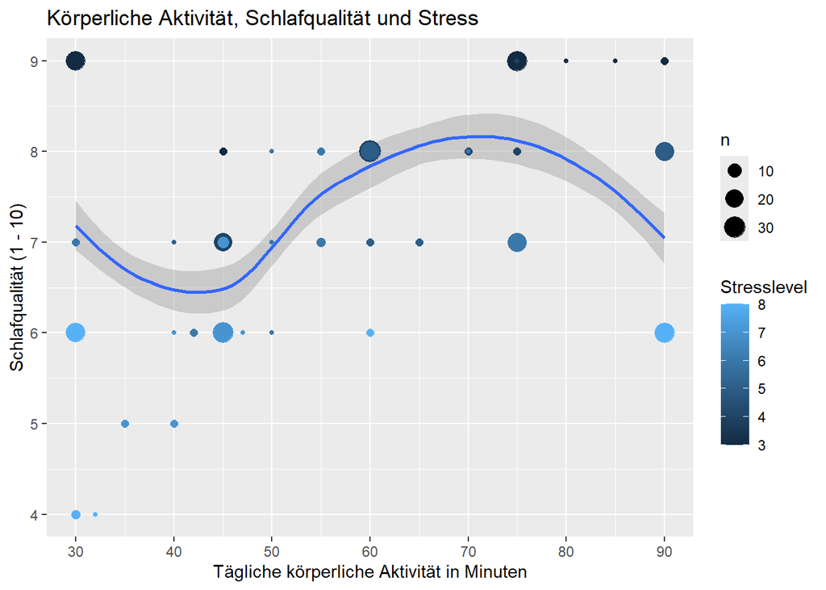

```r
final_sleep_data %>%
  ggplot(
    mapping = aes(x = Physical.Activity.Level, y = Quality.of.Sleep)
  ) +
  geom_smooth() +
  geom_count(mapping = aes(color = Stress.Level)) +
  scale_x_continuous(breaks = seq(0, 100, by = 10)) +
  labs(
    title = "Körperliche Aktivität, Schlafqualität und Stress",
    x = "Tägliche körperliche Aktivität in Minuten",
    y = "Schlafqualität (1 - 10)",
    color = "Stresslevel"
  )
```

Es zeigt sich kein eindeutiger Zusammenhang zwischen körperlicher Aktivität und Schlafqualität. Es lässt sich jedoch ein leichter Anstieg erkennen. Die Korrelation ist leicht positiv und liegt bei **0.1920382**

Zudem sind zwei größere Ausreißer sichtbar. Einen bei guter Schlafqualität trotz körperlicher Aktivität und einen bei schlechter Schlafqualität trotz hoher körperlicher Aktivität. Diese haben jedoch ein hohes und niedriges Stresslevel. Die Schlafqualität ist in diesen Fällen also vom Stresslevel beeinflusst.

**Insgesamt deutet die Analyse darauf hin, dass Stress einen stärkeren Einfluss auf die Schlafqualität hat als die körperliche Aktivität.**

Trotzdem scheint auch die körperliche Aktivität einen leichten Einfluss auf die Schlafqualität zu haben.

Um ein noch genaueres Bild zu erhalten, betrachten wir im Folgenden die Verteilung der Schlafstörungen auf die körperliche Aktivität.

**Code anzeigen**

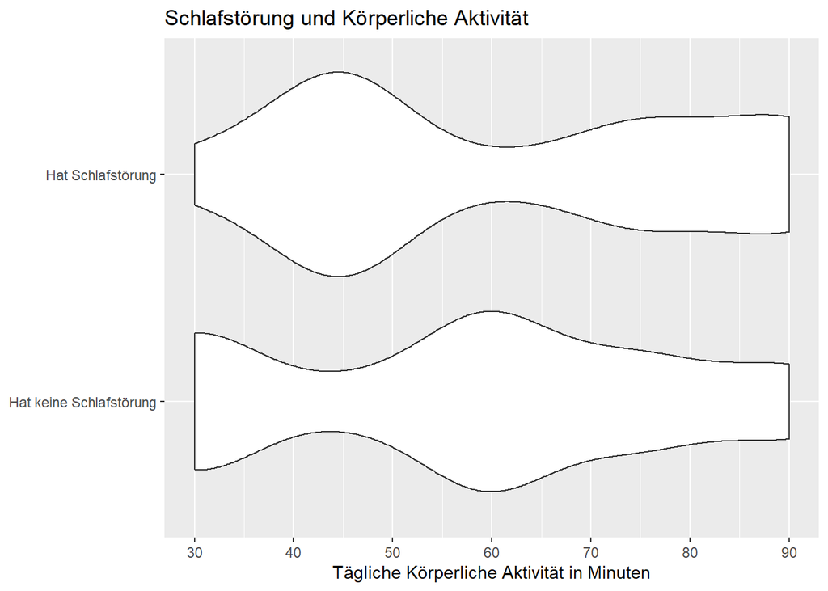

```r
final_sleep_data %>%
  ggplot(
    mapping = aes(x = Physical.Activity.Level, y = Sleep.Disorder)
  ) +
  geom_violin() +
  scale_x_continuous(breaks = seq(0, 100, by = 10)) +
  theme(axis.title.y = element_blank()) +
  labs(
    title = "Schlafstörung und Körperliche Aktivität",
    x = "Tägliche Körperliche Aktivität in Minuten"
  )
```

Die Daten weisen insgesamt eine hohe Spannweite auf. Es ist jedoch eine deutliche Häufung von Personen mit Schlafstörungen im Bereich geringer täglicher körperlicher Aktivität zu erkennen.

Dies korrespondiert mit dem vorherigen Darstellungen und stützt die Annahme, dass mehr körperliche Aktivität die Schlafqualität positiv beeinflusst.

Um den Zusammenhang zwischen körperlicher Aktivität und der Schlafqualität zu untersuchen, schauen wir uns noch die tägliche Schrittzahl an. Die Schrittzahl dient hierbei als weiterer Indikator für die körperliche Aktivität.

**Code anzeigen**

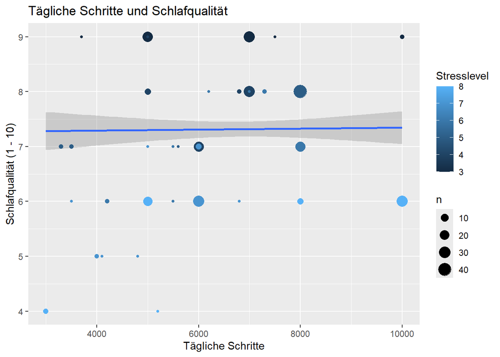

```r
final_sleep_data %>%
  ggplot(
    mapping = aes(x = Daily.Steps, y = Quality.of.Sleep)
  ) +
  geom_smooth(method = "lm") +
  geom_count(mapping = aes(color = Stress.Level)) +
  labs(
    title = "Tägliche Schritte und Schlafqualität",
    x = "Tägliche Schritte",
    y = "Schlafqualität (1 - 10)",
    color = "Stresslevel"
  )
```

Die Schrittzahl zeigt keinen eindeutigen Zusammenhang zur Schlafqualität. Der stärkere Auslöser scheint auch hier das Stresslevel zu sein.

Zusätzlich vergleichen wir, ob die Anzahl der täglichen Schritte einen Zusammenhang mit Schlafstörungen hat.

**Code anzeigen**

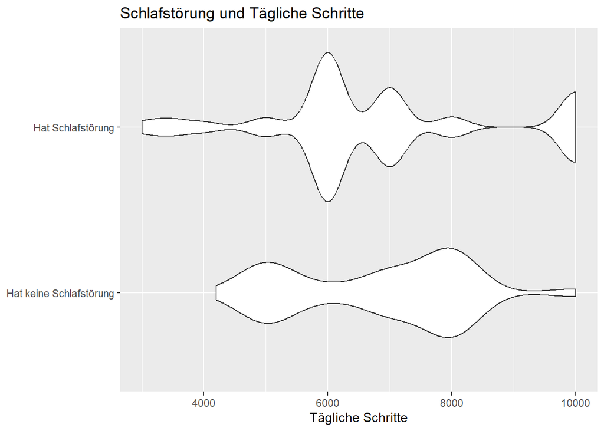

```r
final_sleep_data %>%
  ggplot(
    mapping = aes(x = Daily.Steps, y = Sleep.Disorder)
  ) +
  geom_violin() +
  theme(axis.title.y = element_blank()) +
  labs(
    title = "Schlafstörung und Tägliche Schritte",
    x = "Tägliche Schritte"
  )
```

**Somit kann man aus den Diagrammen schlussfolgern, dass die körperliche Aktivität einen leichten Einfluss auf die Schlafqualität hat.**

Somit lässt sich die These nur zum Teil bestätigen. Viel Stress hat einen großen Einfluss auf die Schlafqualität. Dagegen hat die körperliche Aktivität nur einen leichten Einfluss auf die Schlafqualität.

### Untersuchung der zweiten These

Zunächst werfen wir einen Blick auf den Zusammenhang zwischen Alter und der Schlafqualität.

**Code anzeigen**

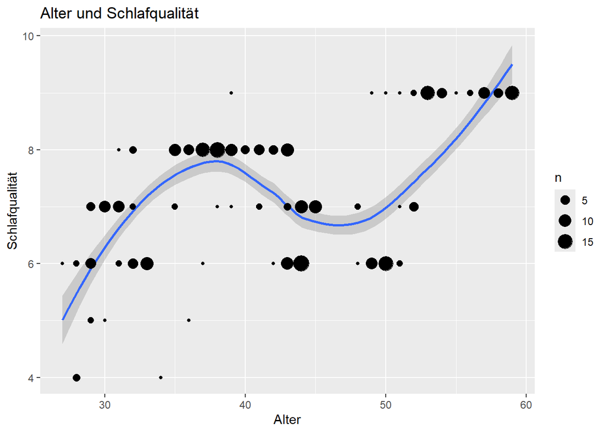

```r
ggplot(
  data = final_sleep_data,
  mapping = aes(x = Age, y = Quality.of.Sleep)
) +
  geom_smooth() +
  geom_count() +
  labs(
    title = "Alter und Schlafqualität",
    x = "Alter", y = "Schlafqualität"
  )
```

In der Grafik ist erkennbar, dass die Schlafqualität mit zunehmendem Alter ansteigt. Sie steigt aber nicht linear. Im Bereich vom Alter 37 bis zum Alter 47 gibt es einen Rückgang der Schlafqualität.

Somit ergibt sich eine leicht positive Korrelation von **0.4712609**.

Schauen wir uns ergänzend dazu noch an, wie sich das Alter auf die Schlafstörungen auswirkt.

**Code anzeigen**

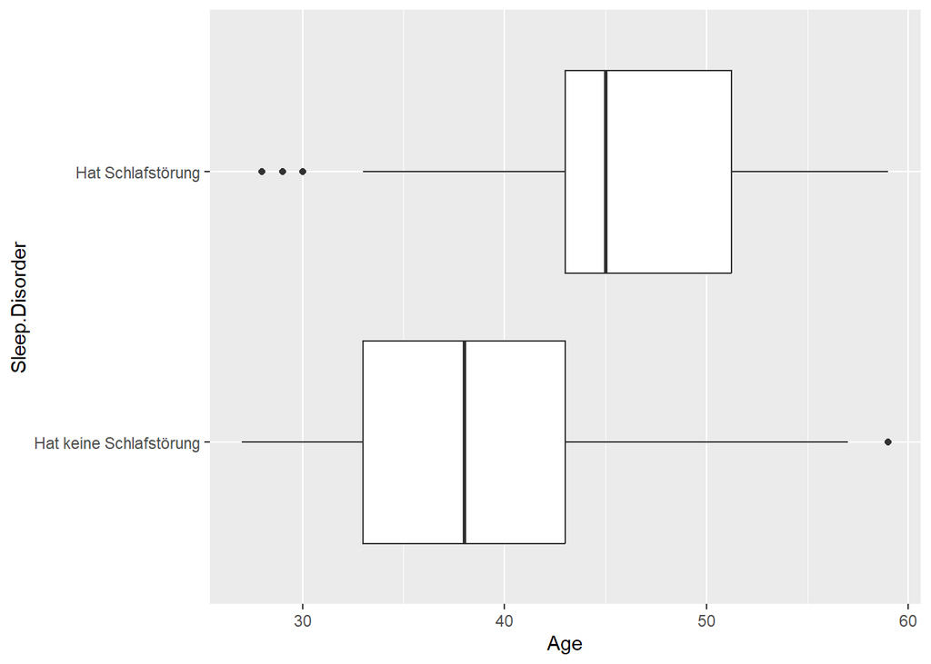

```r
ggplot(
  data = final_sleep_data,
  mapping = aes(x = Age, y = Sleep.Disorder)
) +
  geom_boxplot()
```

Der Graph zeigt, dass Schlafstörungen häufiger im hohen Alter auftreten. Dieses Ergebnis steht im Kontrast zum vorherigen Graphen, der einen Anstieg der Schlafqualität mit zunehmendem Alter zeigt.

Dabei ist jedoch zu berücksichtigen, dass es sich hierbei um eine schwach positive Korrelation handelt. Zudem ist die Schlafqualität eine subjektive Variable. Darüber hinaus verläuft die Entwicklung nicht linear, sondern sinkt zwischendurch.

Alles in allem kann man also sagen, dass der zweite Graph eindeutigere Ergebnisse liefert. Somit wird die am Anfang aufgestellte These bestätigt: Schlafqualität scheint im Alter abzunehmen. Jedoch kann man nicht sagen, dass dies ein eindeutiges Ergebnis ist, da sich die Graphen teilweise widersprechen.

Um ein genaueres Ergebnis zu erhalten, müsste man sich noch weitere Daten anschauen - insbesondere die Daten, die im hohen Alter eine gute Schlafqualität aufweisen, da dies dem zweiten Graphen widerspricht. Man könnte also versuchen, die widersprüchlichen Daten durch andere Faktoren zu interpretieren.

## Daten aufbereiten

Bereiten wir die Daten final auf, um einen trainingsbereiten Datensatz zu erhalten.

**Code anzeigen**

```r
rec <- recipe(Quality.of.Sleep ~ ., data = final_sleep_data_train) %>%
  step_impute_median(all_numeric_predictors()) %>%
  step_dummy(all_nominal_predictors()) %>%
  step_normalize(all_predictors())

prep_rec <- prep(rec)

train_ready <- bake(prep_rec, new_data = NULL)

train_ready
```

```
# A tibble: 297 × 13
     Age Sleep.Duration Physical.Activity.Level Stress.Level BD.Systolisch
   <dbl>          <dbl>                   <dbl>        <dbl>         <dbl>
 1 -1.75          -1.28                 -0.827         0.352        -0.337
 2 -1.64          -1.15                  0.0521        1.47         -0.464
 3 -1.64          -1.15                  0.0521        1.47         -0.464
 4 -1.64          -1.53                 -1.41          1.47          1.44
 5 -1.64          -1.53                 -1.41          1.47          1.44
 6 -1.64          -1.53                 -1.41          1.47          1.44
 7 -1.53          -1.03                 -0.925         0.912         1.44
 8 -1.53          -1.28                 -1.41          1.47         -1.10
 9 -1.53          -1.28                 -1.41          1.47         -1.10
10 -1.53          -1.41                 -1.41          1.47         -1.10
# ℹ 287 more rows
# ℹ 8 more variables: BD.Diastolisch <dbl>, Heart.Rate <dbl>,
#   Daily.Steps <dbl>, Quality.of.Sleep <int>, Gender_Male <dbl>,
#   BMI.Category_1 <dbl>, BMI.Category_2 <dbl>,
#   Sleep.Disorder_Hat.Schlafstörung <dbl>
```

## Modellieren

### Lineare Regression

Trainieren wir zuerst ein **lineares Regressionsmodell**

**Code anzeigen**

```r
lm_model <- linear_reg() %>%
  set_engine("lm")

lm_fit <- lm_model %>%
  fit(Quality.of.Sleep ~ ., data = train_ready)

lm_fit %>%
  extract_fit_engine() %>%
  summary()
```

```
Call:
stats::lm(formula = Quality.of.Sleep ~ ., data = data)

Residuals:
     Min       1Q   Median       3Q      Max
-1.18992 -0.16834 -0.05259  0.18562  1.01776

Coefficients:
                                 Estimate Std. Error t value Pr(>|t|)
(Intercept)                       7.31650    0.01653 442.710  < 2e-16 ***
Age                               0.51444    0.04664  11.030  < 2e-16 ***
Sleep.Duration                    0.11615    0.04817   2.411 0.016533 *
Physical.Activity.Level           0.05344    0.03829   1.395 0.163960
Stress.Level                     -0.75313    0.05252 -14.340  < 2e-16 ***
BD.Systolisch                    -0.31948    0.13817  -2.312 0.021481 *
BD.Diastolisch                    0.29049    0.14369   2.022 0.044145 *
Heart.Rate                        0.00324    0.04279   0.076 0.939700
Daily.Steps                       0.04848    0.04264   1.137 0.256523
Gender_Male                       0.14392    0.02960   4.863 1.92e-06 ***
BMI.Category_1                   -0.17470    0.05232  -3.339 0.000954 ***
BMI.Category_2                    0.20308    0.05209   3.899 0.000121 ***
Sleep.Disorder_Hat.Schlafstörung -0.06870    0.02874  -2.390 0.017506 *
---
Signif. codes:  0 '***' 0.001 '**' 0.01 '*' 0.05 '.' 0.1 ' ' 1

Residual standard error: 0.2848 on 284 degrees of freedom
Multiple R-squared:  0.9449,    Adjusted R-squared:  0.9426
F-statistic:   406 on 12 and 284 DF,  p-value: < 2.2e-16
```

Schauen wir uns die Fehler der Vorhersage auf dem gesamten Trainingsdatensatz an.

**Code anzeigen**

```r
pred_lm <- predict(lm_fit, new_data = train_ready)

compare_lm <- train_ready %>%
  select(Quality.of.Sleep) %>%
  bind_cols(pred_lm)

head(compare_lm)
```

```
# A tibble: 6 × 2
  Quality.of.Sleep .pred
             <int> <dbl>
1                6  5.70
2                6  5.78
3                6  5.78
4                4  4.55
5                4  4.55
6                4  4.55
```

Nun berechnen wir anhand der Ergebnisse den RMSE Wert.

**Code anzeigen**

```r
rmse(compare_lm, Quality.of.Sleep, .pred)
```

```
# A tibble: 1 × 3
  .metric .estimator .estimate
  <chr>   <chr>          <dbl>
1 rmse    standard       0.279
```

Dieser liegt in einem guten Bereich. Somit scheinen die Vorhersagen vom eigentlichen Wert nicht allzu stark abzuweichen.

Zudem führen wir hier noch eine Kreuzvalidierung durch, um potenzielles Overfitting auszuschließen und die Performance des Modells besser herauszufinden.

**Code anzeigen**

```r
cv_splits <- vfold_cv(train_ready, v = 10, strata = Quality.of.Sleep)

lm_model <- linear_reg() %>%
  set_engine("lm")

workflow_spec <- workflow() %>%
  add_model(lm_model) %>%
  add_formula(Quality.of.Sleep ~ .)

cv_results <-
  workflow_spec %>%
  fit_resamples(resamples = cv_splits,
                control = control_resamples(save_pred = TRUE))

cv_results %>% collect_metrics()
```

```
# A tibble: 2 × 6
  .metric .estimator  mean     n std_err .config
  <chr>   <chr>      <dbl> <int>   <dbl> <chr>
1 rmse    standard   0.297    10 0.0162  pre0_mod0_post0
2 rsq     standard   0.942    10 0.00581 pre0_mod0_post0
```

Der RMSE Wert hat sich nur leicht verschlechtert, somit können wir Overfitting ausschließen

Um zu schauen ob ein anderes Modell noch besser performen kann, schauen wir uns ein weiteres Modell an.

### Entscheidungsbaum

Als nächstes schauen wir und das **Entscheidungsbaum** Modell an.

**Code anzeigen**

```r
tree_mod <- decision_tree(mode = "regression")

tree_fit <- tree_mod %>%
  fit(Quality.of.Sleep ~ ., data = train_ready)
```

Betrachten wir auch hier die Fehler der Vorhersage auf dem gesamten Trainingsdatensatz.

**Code anzeigen**

```r
pred_tree <- predict(tree_fit, new_data = train_ready)

compare_tree <- train_ready %>%
  select(Quality.of.Sleep) %>%
  bind_cols(pred_tree)

head(compare_tree)
```

```
# A tibble: 6 × 2
  Quality.of.Sleep .pred
             <int> <dbl>
1                6  6.90
2                6  6.04
3                6  6.04
4                4  4.57
5                4  4.57
6                4  4.57
```

**Code anzeigen**

```r
rmse(compare_tree, Quality.of.Sleep, .pred)
```

```
# A tibble: 1 × 3
  .metric .estimator .estimate
  <chr>   <chr>          <dbl>
1 rmse    standard       0.269
```

Der RMSE Wert fällt besser aus, als der RMSE vom *Linearen Regressions* Modell, somit scheint das Modell erstmal besser zu performen.

Aber auch hier führen wir zudem noch eine Kreuzvalidierung durch.

**Code anzeigen**

```r
cv_splits <- vfold_cv(train_ready, v = 10, strata = Quality.of.Sleep)

model_spec <- decision_tree() %>%
  set_mode("regression")

workflow_spec <- workflow() %>%
  add_model(model_spec) %>%
  add_formula(Quality.of.Sleep ~ .)

cv_results <-
  workflow_spec %>%
  fit_resamples(resamples = cv_splits,
                control = control_resamples(save_pred = TRUE))

cv_results %>% collect_metrics()
```

```
# A tibble: 2 × 6
  .metric .estimator  mean     n std_err .config
  <chr>   <chr>      <dbl> <int>   <dbl> <chr>
1 rmse    standard   0.287    10  0.0376 pre0_mod0_post0
2 rsq     standard   0.941    10  0.0125 pre0_mod0_post0
```

Die Kreuzvalidierung ergibt einen höheren RMSE Wert. Dieser ist ähnlich hoch wie der RMSE Wert der linearen Regression.

Somit versuchen wir es mit einem weiteren Modell.

### Random Forest

Trainieren wir also das **Random Forest** Modell.

**Code anzeigen**

```r
forest_mod <- rand_forest(trees = 1000)  %>%
    set_mode("regression")

forest_fit <- forest_mod %>%
  fit(Quality.of.Sleep ~ ., data = train_ready)
```

Schauen wir uns die Fehler der Vorhersage auf dem gesamten Trainingsdatensatz an.

**Code anzeigen**

```r
pred_forest <- predict(forest_fit, new_data = train_ready)

compare_forest <- train_ready %>%
  select(Quality.of.Sleep) %>%
  bind_cols(pred_forest)

head(compare_forest)
```

```
# A tibble: 6 × 2
  Quality.of.Sleep .pred
             <int> <dbl>
1                6  5.95
2                6  6.00
3                6  6.00
4                4  4.17
5                4  4.17
6                4  4.17
```

**Code anzeigen**

```r
rmse(compare_forest, Quality.of.Sleep, .pred)
```

```
# A tibble: 1 × 3
  .metric .estimator .estimate
  <chr>   <chr>          <dbl>
1 rmse    standard       0.100
```

Hier haben wir den geringsten RMSE Wert von allen bisher verwendeten Modellen.

Um ein potenzielles Overfitten auszuschließen führen wir auch hier eine Kreuzvalidierung durch.

**Code anzeigen**

```r
cv_splits <- vfold_cv(train_ready, v = 10, strata = Quality.of.Sleep)

model_spec <- rand_forest(trees = 1000) %>%
  set_mode("regression")

workflow_spec <- workflow() %>%
  add_model(model_spec) %>%
  add_formula(Quality.of.Sleep~.)

cv_results <-
  workflow_spec %>%
  fit_resamples(resamples = cv_splits,
                control = control_resamples(save_pred = TRUE))

cv_results %>% collect_metrics()
```

```
# A tibble: 2 × 6
  .metric .estimator  mean     n std_err .config
  <chr>   <chr>      <dbl> <int>   <dbl> <chr>
1 rmse    standard   0.204    10 0.0333  pre0_mod0_post0
2 rsq     standard   0.969    10 0.00769 pre0_mod0_post0
```

Alles in allem performt also das **Random Forest** Modell am besten. Somit werden wir dies auch verwenden.

## Modelle optimieren

Nun optimieren wir das **Random Forest** Modell noch.

Wir verwenden dazu ein reguläres Grid um die beste Kombination der Parameter **mtry** und **min_n** zu finden.

**Code anzeigen**

```r
# Quelle: [1]
forest_mod <- rand_forest(mtry = tune(), min_n = tune(), trees = 1000)  %>%
    set_mode("regression")

forest_folds <- vfold_cv(final_sleep_data_train, strata = Quality.of.Sleep)

forest_wflow <- workflow() %>%
  add_model(forest_mod) %>%
  add_recipe(rec)

forest_param <- forest_wflow %>%
  extract_parameter_set_dials() %>%
  update(
    mtry = mtry(c(1, 12))
  )

forest_tune <- forest_wflow %>%
  tune_grid(
    forest_folds,
    grid = forest_param %>% grid_regular(levels = 3),
    metrics = metric_set(rmse)
  )

best_param <- select_best(forest_tune, metric = "rmse")

best_param
```

```
# A tibble: 1 × 3
   mtry min_n .config
  <int> <int> <chr>
1    12     2 pre0_mod7_post0
```

Mit den Parametern trainieren wir ein optimiertes Random Forest Modell.

**Code anzeigen**

```r
final_forest_mod <- rand_forest(mtry = best_param$mtry, min_n = best_param$min_n, trees = 1000)  %>%
    set_mode("regression")

final_forest_fit <- final_forest_mod %>%
  fit(Quality.of.Sleep ~ ., data = train_ready)
```

## Modell beurteilen

Baken wir den Testdatensatz zuerst um unseren finalen Testdatensatz zu bekommen.

**Code anzeigen**

```r
test_ready <- bake(prep_rec, new_data = final_sleep_data_test)
```

Nun testen wir unser Modell mit dem fertigen Testdatensatz.

**Code anzeigen**

```r
pred_test <- predict(final_forest_fit, new_data = test_ready)

compare_test <- final_sleep_data_test %>%
  select(Quality.of.Sleep) %>%
  bind_cols(pred_test)

head(compare_test)
```

```
# A tibble: 6 × 2
  Quality.of.Sleep .pred
             <int> <dbl>
1                7  7
2                7  7
3                7  7.00
4                5  5.27
5                6  6
6                7  7
```

Schauen wir uns final noch den RMSE Wert an.

**Code anzeigen**

```r
rmse(compare_test, Quality.of.Sleep, .pred)
```

```
# A tibble: 1 × 3
  .metric .estimator .estimate
  <chr>   <chr>          <dbl>
1 rmse    standard       0.105
```

Dieser liegt in einem niedrigen Bereich.

# Evaluieren

Allem im allem kann man sagen, dass das Modell *Random Forest* am besten bei diesem Datensatz performt. Dies konnten wir durch das Vergleichen der RMSE Werte festlegen.

Durch das tunen der Parameter *mtry* und *min_n* konnten wir die Performance noch verbessern. Somit haben wir am Ende ein gut performendes Modell mit dem sich gut weiterarbeiten lässt.

Natürlich ist der Datensatz noch klein, somit müsste man das Modell auch mit mehr Daten testen um ein genaueres Ergebnis zu bekommen. Auch die Schlussfolgerung der Explorativen Datenanalyse würde durch mehr Daten und das einbeziehen von mehr Variablen ein eindeutigeres Ergebnis liefern.

# Quellen

[1] https://www.tmwr.org/grid-search